# How many children of primary school age are not in school?

[interactive chart not shown]

## The impact of economic growth on the situation in two world regions

#### The first graph demonstrates that economic growth decreases the number of children out of school. The second graphic proves the first statement by showing a positive trend in school enrollment for the same period of time.

[interactive chart not shown]

## The difference between boys and girls not attempting school

#### Equal number of males and females attempting school is what we want. Sub-Saharan Africa still have a lot of work to do since there is a big difference between boys and girls.

[interactive chart not shown]

## The reasons why children do not attempt school

### Child Marriage

#### Child marriage means that women stop school earlier or do not attempt school at all.

[interactive chart not shown]

### Child Labor

#### Child labor is one more reason why children do not get appropriate level of primary education

[interactive chart not shown]

## Forecast

#### The following visualization shows a share of the population with no primary education. These figures suggest that we should see rates of education increasing as the world develops by 2050.

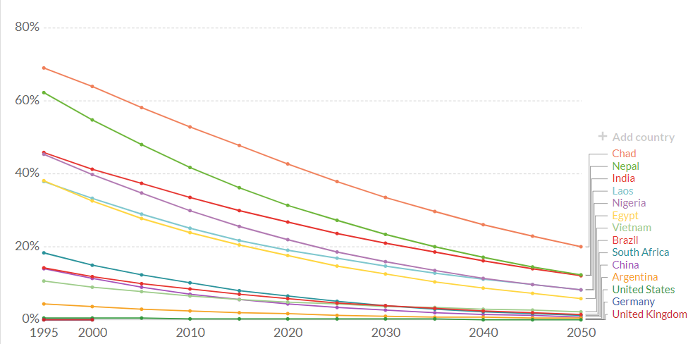

## Actions that need to be done to improve the situation

Despite the positive trend in all world regions, some actions still need to be done in order to meet our target of free, quality education for all by 2030.  
Here is a liast of possible directions:  
1) Child labor in all developing countries have to be banned as well as child marriage  
2) Society should work toward gender equality since girls more often do not attemt school than boys  
3) Children do not meet the appropriate level of education because of poverty. More efforts should be focused on economy growth since this parameter reduces the number of children which do not attempt school.